# Practical Machine Learning - Course Project

## Executive Summary

Using devices such as JawboneUp, NikeFuelBand, and Fitbitit is now possible to collect a large amount of data about personal activity relatively inexpensively. These type of devices are part of the quantified self movement - a group of enthusiasts who take measurements about themselves regularly to improve their health, to find patterns in their behavior, or because they are tech geeks. One thing that people regularly do is quantify how much of a particular activity they do, but they rarely quantify how well they do it.

This report examines data from accelerometers on the belt, forearm, arm, and dumbell of 6 research study participants. They were asked to perform barbell lifts correctly and incorrectly in 5 different ways. By exploring the data, we will develop models allowing the prediction of the manner in which exercises are performed.

The training data for this analysis are available here: https://d396qusza40orc.cloudfront.net/predmachlearn/pml-training.csv

The test data are available here: https://d396qusza40orc.cloudfront.net/predmachlearn/pml-testing.csv

More information is available from the website: http://groupware.les.inf.puc-rio.br/har (see the section on the Weight Lifting Exercise Dataset).

## Load required libraries and set seed

```r
require(caret)
require(rpart)
require(rpart.plot)
require(RColorBrewer)
require(rattle)
require(randomForest)
set.seed(314)
```

## Load and clense the data

```r
options( stringsAsFactors = FALSE )

# read the pml-training data
pml_training <- read.csv(url("http://d396qusza40orc.cloudfront.net/predmachlearn/pml-training.csv"), na.strings=c("NA","#DIV/0!",""), header=TRUE, as.is = TRUE)

# read the pml-testing data
pml_testing <- read.csv(url("http://d396qusza40orc.cloudfront.net/predmachlearn/pml-testing.csv"), na.strings=c("NA","#DIV/0!",""), header=TRUE, as.is = TRUE)

# Factorize classe since we can't use string as y for most ML
pml_training$classe <- as.factor(pml_training$classe)

# let's clean the pml-training data, starting with a copy we can work with
clean_training <- pml_training
```

### Zap variables not influencing analysis (sequence, user name, and timestamp data)

```r
clean_training <- clean_training[, -(1:5)]
```

### Remove columns with nearly all more than 95% NAs

```r
tmp <- sapply(clean_training, function (x) sum(is.na(x))/dim(clean_training)[1])
clean_training <- clean_training[names(tmp[tmp < .95])]
rm(tmp)
```

### Remove Near Zero Variance predictors from training sets

```r
tmp <- nearZeroVar(clean_training, saveMetrics = TRUE)
clean_training <- clean_training[, tmp$nzv == FALSE]
rm(tmp)
```

## Partition data into training and testing sets

```r
# split training set 80/20
trainingSet = createDataPartition(clean_training$classe, p = 0.8, list = FALSE)
local_training = clean_training[trainingSet,]
local_testing = clean_training[-trainingSet,]
rm(clean_training)
```

## Generate Decision Tree ML model

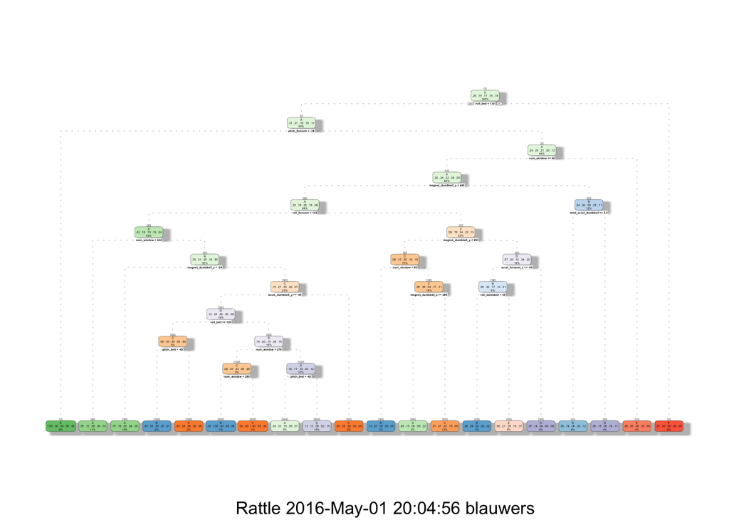

```r
modelDecisionTree <- rpart(classe ~ ., data=local_training, method="class")
fancyRpartPlot(modelDecisionTree)
```

```r
# Use the model to generate predictions
predictionsDecisionTree <- predict(modelDecisionTree, local_testing, type = "class")

# Get confusion Matrix and Statistics
cmDecisionTree <- confusionMatrix(predictionsDecisionTree, local_testing$classe)
round( cmDecisionTree$overall, 3 )
```

```
##       Accuracy          Kappa  AccuracyLower  AccuracyUpper   AccuracyNull
##          0.742          0.671          0.728          0.755          0.284
## AccuracyPValue  McnemarPValue
##          0.000          0.000
```

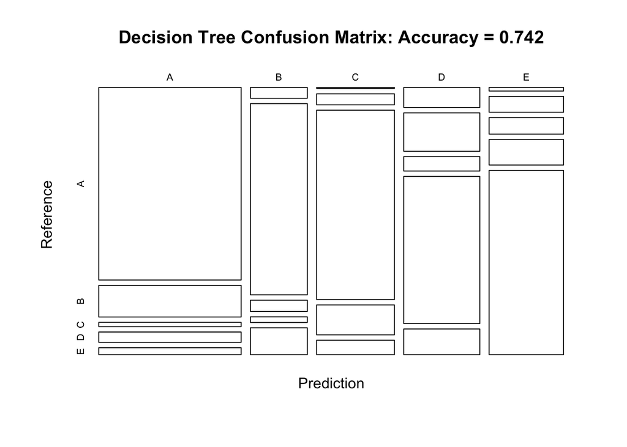

```r
plot(cmDecisionTree$table, col = cmDecisionTree$byClass, main = paste("Decision Tree Confusion Matrix: Accuracy =", round(cmDecisionTree$overall['Accuracy'], 3)))
```

## Generate Random Forest ML model

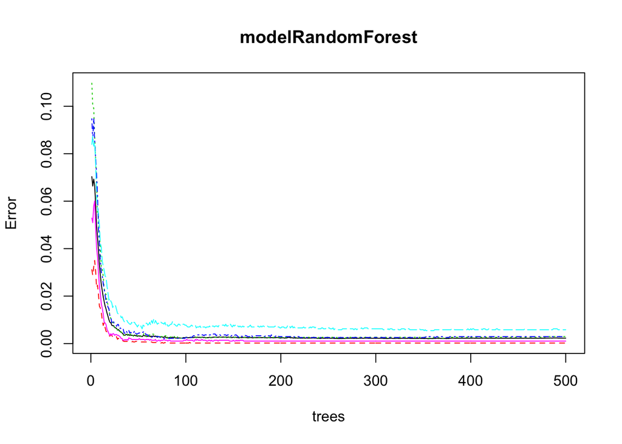

```r
modelRandomForest <- randomForest(classe ~. , data=local_training)
plot(modelRandomForest)
```

```r
predictionsRandomForest <- predict(modelRandomForest, local_testing, type = "class")
cmRandomForest <- confusionMatrix(predictionsRandomForest, local_testing$classe)
round( cmRandomForest$overall, 3 )
```

```
##       Accuracy          Kappa  AccuracyLower  AccuracyUpper   AccuracyNull
##          0.998          0.998          0.997          0.999          0.284
## AccuracyPValue  McnemarPValue
##          0.000            NaN
```

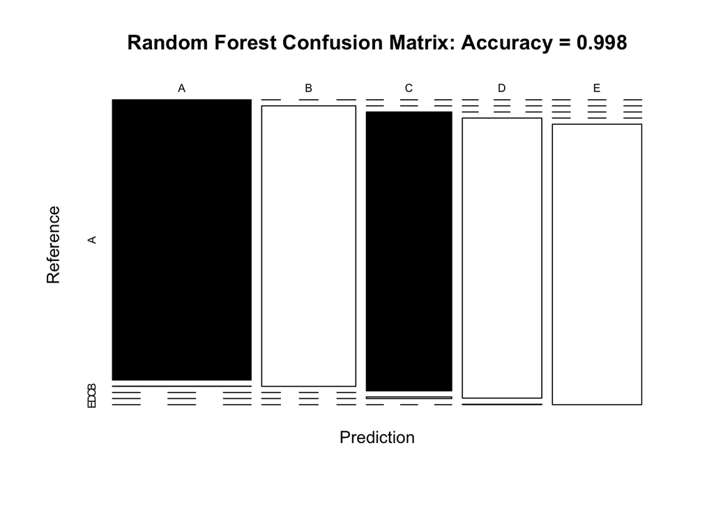

```r
plot(cmRandomForest$table, col = cmRandomForest$byClass, main = paste("Random Forest Confusion Matrix: Accuracy =", round(cmRandomForest$overall['Accuracy'], 3)))
```

```r
# out of sample error
round( (1 - sum(predictionsRandomForest == local_testing$classe)/length(predictionsRandomForest)) * 100, 3)
```

```
## [1] 0.153
```

## Generate Generalized Boosted Regression ML model

```r
modelGeneralizedBoostRegression <-
        train(classe ~ ., data=local_training, method = "gbm", verbose = FALSE,
                 trControl = trainControl(
                                method = "repeatedcv",
                                number = 5,
                                repeats = 1))
```

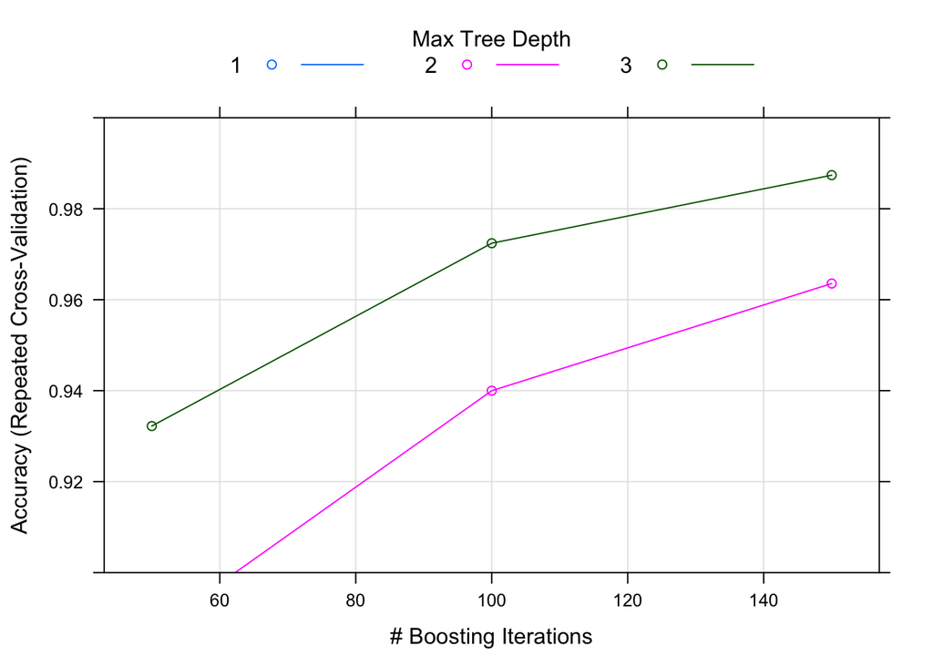

```r
plot(modelGeneralizedBoostRegression, ylim=c(0.9, 1))
```

```r
predictionsGeneralizedBoostRegression <- predict(modelGeneralizedBoostRegression, newdata=local_testing)
cmGeneralizedBoostRegression <- confusionMatrix(predictionsGeneralizedBoostRegression, local_testing$classe)
round( cmGeneralizedBoostRegression$overall, 3 )
```

```
##       Accuracy          Kappa  AccuracyLower  AccuracyUpper   AccuracyNull
##          0.989          0.986          0.986          0.992          0.284
## AccuracyPValue  McnemarPValue
##          0.000            NaN
```

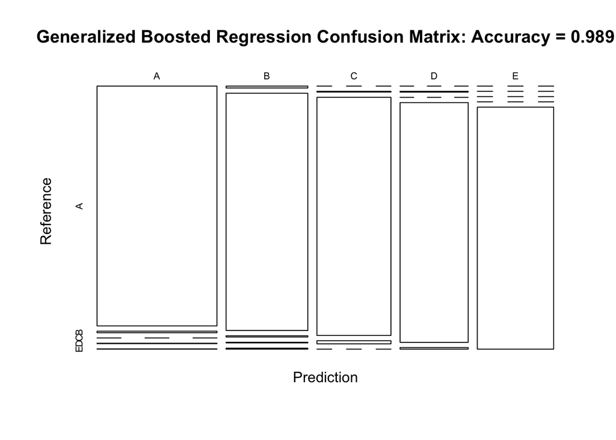

```r
plot(cmGeneralizedBoostRegression$table, col = cmGeneralizedBoostRegression$byClass, main = paste("Generalized Boosted Regression Confusion Matrix: Accuracy =", round(cmGeneralizedBoostRegression$overall['Accuracy'], 3)))
```

## Evaluating the model on the test data

Results omitted per the Coursera Honor Code.

```r
predictionsEvaluation <- predict(modelRandomForest, pml_testing, type = "class")
```